# Lab 8b

GAO Zheng

November 2, 2016

Now you can download the RMarkdown file by clicking the button in the rupper right corner of this html page.

## Rejection sampling

Idea: Simulate random variables (pair of coordinates) distributed uniformly over the region under the density curve ($F$). However doing so directly may be difficult.

Simulate a random variables uniformly in a region that encapsulates the target density.

i.e. simulate from $Y \sim g$, $U \sim \mathrm{U}(0, Mg(Y))$, where $Mg(t) \ge f(t)$ everywhere.

Algorithm (Rejection Sampling)

1. Generate $Y \sim g$ and generate $U \sim \mathrm{U}(0, Mg(Y))$.
2. If $U \le f(Y)$, Stop and return $Y$.
3. Otherwise, reject $Y$ and go back to Step 1.

Here is an equivalent version:

Algorithm (Rejection Sampling)

1. Generate $Y ~ g$ and generate $U \sim \mathrm{U}(0, 1)$.
2. If $UMg(Y) \le f(Y)$, Stop and return $Y$.
3. Otherwise, reject $Y$ and go back to Step 1.

Overall efficiency of the algorithm is $1/M$. Therefore we would like the constant $M$ to be as small as possible (M cannot be less than 1; why?).

#### Example

simulate circular distribution on $[-1,1]$ using standard normal as the proposal distribution.

```r
xseq <- seq(-2,2,0.01)
f <- function(x){
  2/pi*sqrt(pmax(1-x^2,rep(0,length(x))))
}
plot(xseq,f(xseq),'l',ylim=c(0,1),ylab = "f(x)",xlab="x",main = "density of target and proposals")
lines(xseq,dnorm(xseq),'l',col=4,lty=2)
```

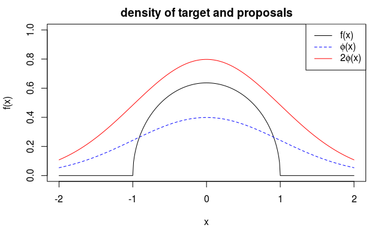

```r
lines(xseq,2*dnorm(xseq),'l',col=2)
legend("topright",
       legend=c('f(x)',
                expression(paste(phi,'(x)')),
                expression(paste('2',phi,'(x)'))),
       col=c(1,4,2),lty = c(1,2,1))
```

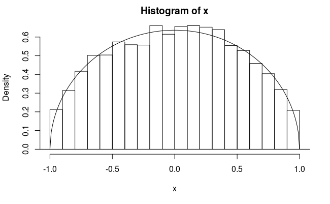

```r
rejection_sampling <- function(n)
{
  ## constant M
  M <- 2

  ## Initialize the output
  x <- rep(0, n)

  k <- 0 ## Number of accepted samples
  ## While loop until there are n accepted samples
  while (k <= n)
  {
    y <- rnorm(1)
    u <- runif(1)
    if (u*M*dnorm(y) <= f(y))
    {
      k <- k + 1
      x[k] <- y
    }
  }
  return(x)
}
x <- rejection_sampling(10000)
hist(x, breaks=20,prob = TRUE)
lines(xseq,f(xseq),'l')
```

**Remarks**

- We only need to know f up to a constant factor (why?). This is helpful when the normalizing constant for f(x) is expensive to compute.

$$\begin{aligned}
\mathrm{P}[X_i\in [a,b]~\big|~X_i~\mathrm{accepted}]
&= \frac{\mathrm{P}[X_i\in [a,b], X_i~\mathrm{accepted}]}{\mathrm{P}[X_i~\mathrm{accepted}]}\\
&= \frac{\mathrm{E}\big[\mathrm{P}[X_i\in [a,b], X_i~\mathrm{accepted}~\big|~Y_i]\big]} {\mathrm{P}[X_i~\mathrm{accepted}]}\\
&= \frac{\int_a^b\mathrm{P}[X_i~\mathrm{accepted}~\big|~Y_i=y]g(y)\mathrm{d}y} {\int_{-\infty}^{\infty}\mathrm{P}[X_i~\mathrm{accepted}~\big|~Y_i=y]g(y)\mathrm{d}y}\\
&= \frac{\int_a^b \frac{f(y)}{Mg(y)} g(y)\mathrm{d}y} {\int_{-\infty}^{\infty}\frac{f(y)}{Mg(y)}g(y)\mathrm{d}y}\\
&= \frac{\int_a^b {f(y)}\mathrm{d}y}{\int_{-\infty}^{\infty}f(y)\mathrm{d}y}
\end{aligned}$$

- Best rejection sampling can do: choose a proper M such that $f(x) \le Mg(x)$ but f(x) and M g(x) as close as possible. i.e. M as small as possible; best choice of M is

$$M^* = \mathrm{sup}_x \frac{f(x)}{g(x)}$$